# Mini Project

12/11/19

## Rockfish Larval Abundance and Environmental Conditions

[figure not shown]

## Importing Packages

1. dplyr
2. ggplot2
3. tidyr
4. kableExtra

[figure not shown]

## Raw Data/Manipulation

1. Raw data orginally came from Raw larval abundance and environmental data for Thompson et al.
2. Raw data includes 27 rockfish speices and 23 environmental/descriptive factors.
3. There are about 10,000 pieces of data in the raw data set.
4. Some of the descriptive factors were not needed for the analysis and were cut out using dplyr.
5. A new column was added using knitr to gather species into a genus column.

## Data Table

The new data set is shown here:

Rockfish Data Table

| temp_surf | sal_surf | oxygen_surf | temp_100m | sal_100m | oxygen_100m | genus |
| --- | --- | --- | --- | --- | --- | --- |
| 17.92000 | 34.04833 | 5.300 | 17.60500 | 34.00686 | 5.095385 | auriculatus |
| 18.06000 | 34.06867 | 5.375 | 17.40167 | 33.98783 | 4.950909 | auriculatus |
| 16.06000 | 33.50033 | 5.665 | 15.75400 | 33.49993 | 5.595000 | auriculatus |
| 16.17667 | 33.51467 | 5.640 | 16.05353 | 33.50829 | 5.625000 | auriculatus |
| 16.57000 | 33.65633 | 5.655 | 14.87000 | 33.71073 | 4.535000 | auriculatus |
| 16.57667 | 33.69933 | 5.630 | 15.95533 | 33.64647 | 5.435000 | auriculatus |
| 17.21333 | 33.87300 | 5.520 | 16.32143 | 33.76943 | 5.182308 | auriculatus |

## Overview on Data

- A total of 16 years of data collected along Californian Coast.
- Rockfish were historically targeted by fishing for many years.
- Environmental factors consist of

  -temperatures

[figure not shown]

  -salinities

[figure not shown]

  -oxygen concentrations

[figure not shown]

## Rockfish at Surface Temp and Temp at 100m

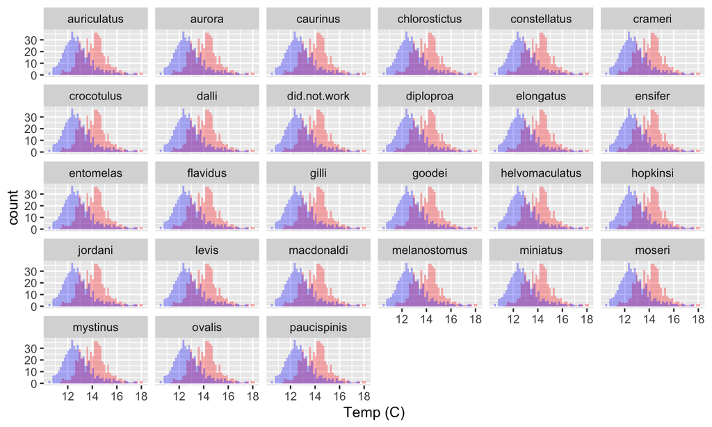

Blue: 100 meters deep Red: surface

## Rockfish at Surface Salinity and Salinity at 100m

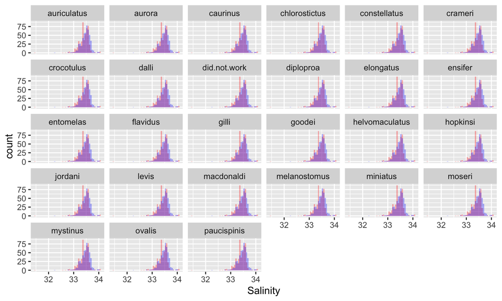

## Rockfish at Surface O2 Concentration and O2 Concentration at 100m

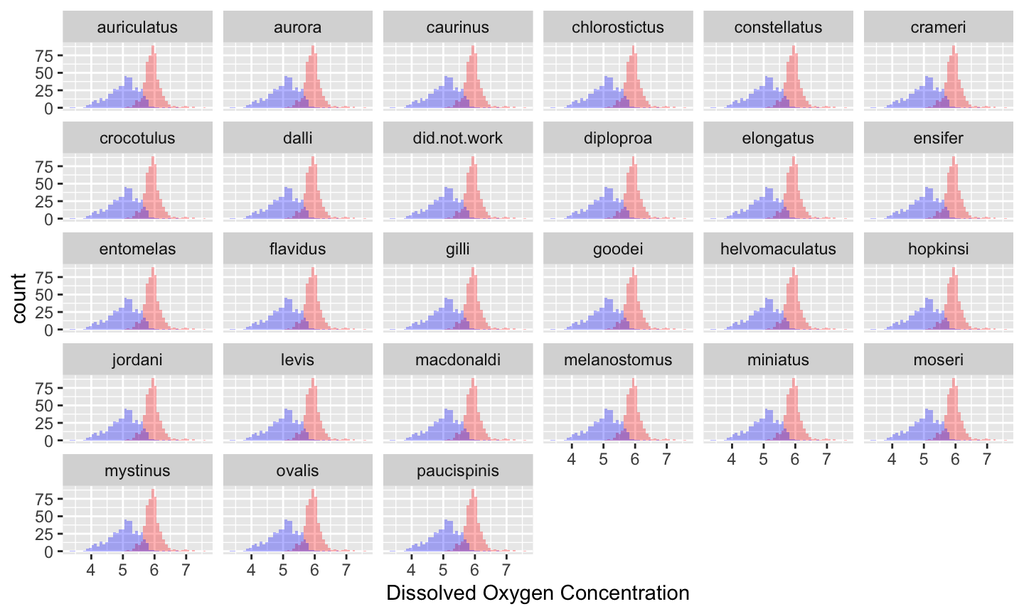

## The Code for Histograms

ggplot(rockfish_data_added_genus, aes(x=temp_surf)) + geom_histogram(fill=“red”, alpha = 0.3, bins = 50) + labs(x = “Temp (C)”) + facet_wrap(~genus) + geom_histogram(aes(x=temp_100m), fill=“blue”, alpha = 0.3, bins = 50)

[figure not shown]

## Thank you!

### Any Questions?

[figure not shown]